# Deconvolution of spatial sequencing data with SpatialLiger

Joshua Sodicoff

9/8/2020

This vignette will demonstrate `SpatialLiger` (working title), an iNMF-based method for deconolving spatial transcriptomic data.

## Liger workflow

`SpatialLiger` requires four data objects to run * A DGE matrix of spatial transcriptomic data * A DGE matrix of single cell data from the same tissue * A data frame of coordinates for each sample in the spatial data * A named vector of cell type assignments for each cell in the single cell data

```r
macosko[1:5,1:5]
```

```
## 5 x 5 sparse Matrix of class "dgTMatrix"
##         pBICCNsMMrMOpRMiF008d190314_CGTAGTACAGAACTCT
## Xkr4                                              13
## Sox17                                              .
## Mrpl15                                             1
## Gm37988                                            .
## Tcea1                                              1
##         pBICCNsMMrMOpRPiM008d190320_CTACCTGCACATTCTT
## Xkr4                                               4
## Sox17                                              .
## Mrpl15                                             .
## Gm37988                                            .
## Tcea1                                              .
##         pBICCNsMMrMOpRAiF005d190318_ACGTTCCAGACGCATG
## Xkr4                                              42
## Sox17                                              .
## Mrpl15                                             .
## Gm37988                                            .
## Tcea1                                              1
##         pBICCNsMMrMOpRMiF006d190314_ACTCTCGGTTGTATGC
## Xkr4                                               8
## Sox17                                              .
## Mrpl15                                             .
## Gm37988                                            .
## Tcea1                                              .
##         pBICCNsMMrMOpRMiM002d190320_CGATGGCTCCACATAG
## Xkr4                                              14
## Sox17                                              .
## Mrpl15                                             1
## Gm37988                                            1
## Tcea1                                              2
```

```r
coords[1:5,]
```

```
##                    row col
## AAACAGAGCGACTCCT-1  14  94
## AAACCGGGTAGGTACC-1  42  28
## AAAGGGATGTAGCAAG-1  24  62
## AAATAACCATACGGGA-1  14  88
## AAATCGTGTACCACAA-1  44  56
```

```r
cortex[1:5,1:5]
```

```
##         AAACAGAGCGACTCCT-1 AAACCGGGTAGGTACC-1 AAAGGGATGTAGCAAG-1
## Xkr4                     0                  0                  0
## Gm1992                   0                  0                  0
## Gm37381                  0                  0                  0
## Rp1                      0                  0                  0
## Sox17                    0                  0                  2
##         AAATAACCATACGGGA-1 AAATCGTGTACCACAA-1
## Xkr4                     0                  0
## Gm1992                   0                  0
## Gm37381                  0                  0
## Rp1                      0                  0
## Sox17                    0                  0
```

```r
assignments[1:5]
```

```
## pBICCNsMMrMOpRMiF008d190314_CGTAGTACAGAACTCT
##                                      L2/3 IT
## pBICCNsMMrMOpRPiM008d190320_CTACCTGCACATTCTT
##                                        L5 IT
## pBICCNsMMrMOpRAiF005d190318_ACGTTCCAGACGCATG
##                                          Sst
## pBICCNsMMrMOpRMiF006d190314_ACTCTCGGTTGTATGC
##                                        L5 IT
## pBICCNsMMrMOpRMiM002d190320_CGATGGCTCCACATAG
##                                        L5 ET
## 22 Levels: CR Lamp5 Sncg Vip Sst Pvalb L2/3 IT L5 IT L6 IT L5 ET ... Macrophage
```

First, we need to generate and process a Liger object with our single cell data. Here, we’re using 10X V3 single nucleus sequencing of the primary motor cortex from the Macosko Lab. We run Liger, through quantile normalization on the object. You can usually use default parameters for most functions and get a good result, however K should be larger than the number of cell types you are looking to find.

```r
mac_liger = createLiger(list(mac = macosko))
mac_liger %<>% normalize %>% selectGenes %>% scaleNotCenter %>% optimizeALS(k = 30) %>% quantile_norm
```

Then, we preprocess the spatial data. To add the coordinatesm normalize, and scale, the `makeSpatial` and `preprocessSpatial` functions are used.

```r
cortex_liger = createLiger(list(cortex = cortex))
cortex_liger %<>% makeSpatial(coords) %>% preprocessSpatial
```

With both objects processed, we can run the deconvolution with the `deconvolveWithSingleCell` function. The function can take a large number of parameters beyond the two data objects and the single cell assignments, including:

- counts, a vector of the expected number of cells in each sample in the spatial data
- specificity, a factor by which a factor must be the most significant by in assignment
- p_thresh, a value for which a factor must be <10^-p_thresh in assignment
- return.plots = TRUE (fix in the code)
- lambda, the penalty factor for dataset-specific gene loading in the deconvolution
- use.solvennls, whether to use a fast, non-iterative deconvolution
- nrep, how many random starts to use in deconvolution

```r
cortex_liger = deconvolveWithSingleCell(mac_liger, cortex_liger, assignments)
```

One current limitation of the current setup is that rerunning `deconvolveWithSingleCell` or `makeSpatial` multiple times can screw up the object. So, if you deconvolve, direct it into a new object.

After deconvolving, we can use `plotSpatialFeatures` to see the spatial distribution of gene expression, factor loading, or expected cell type. The `genes` and `cell.types` parameters take character vectors of genes and known cell types, whereas `factors` takes a vector of integers. If `return.plots = TRUE` then the function will return a list of requested plots

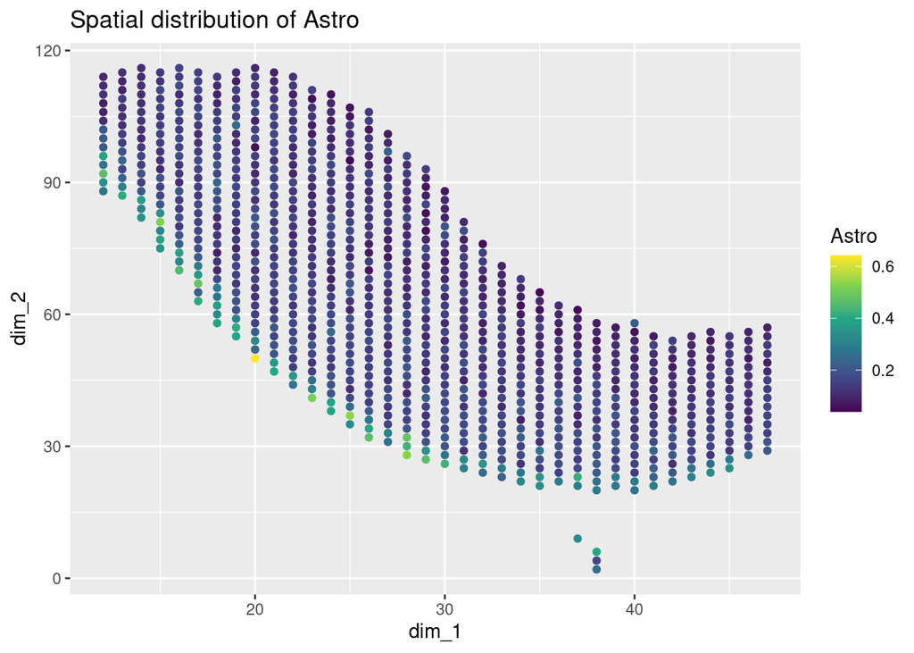

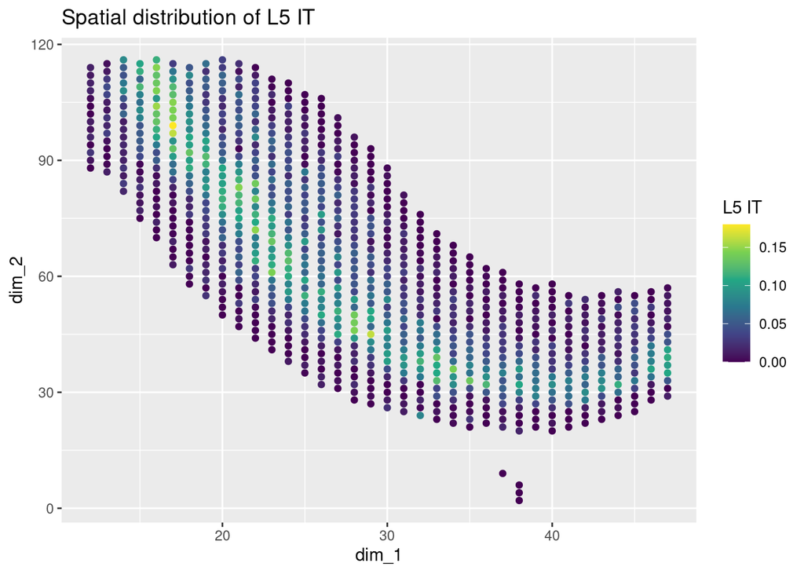

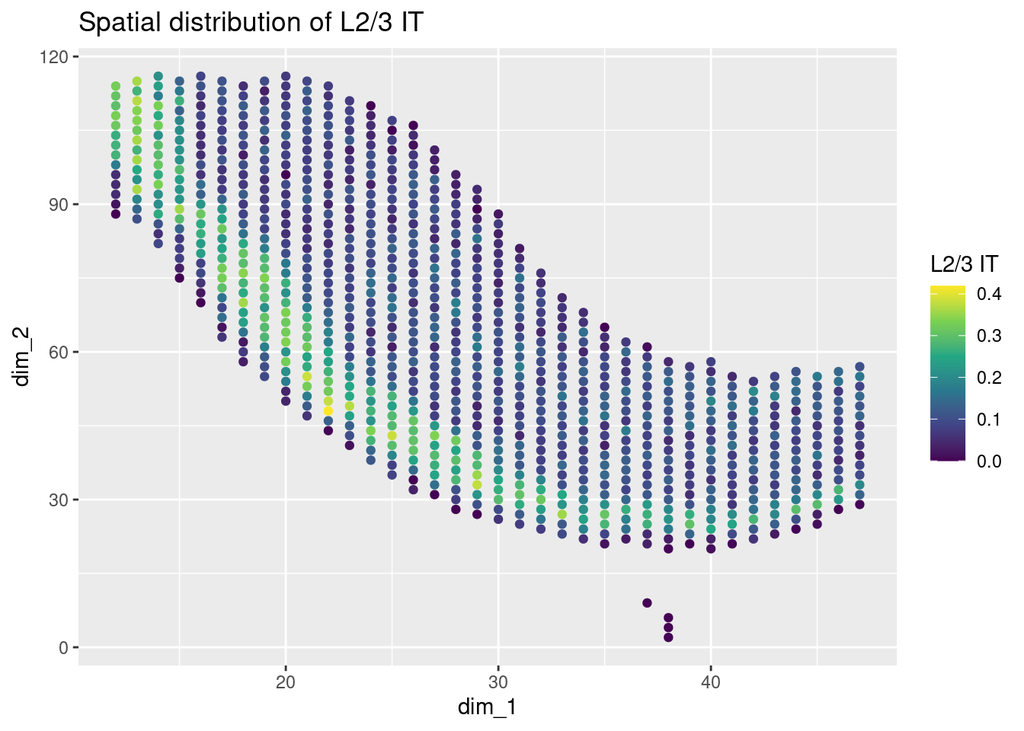

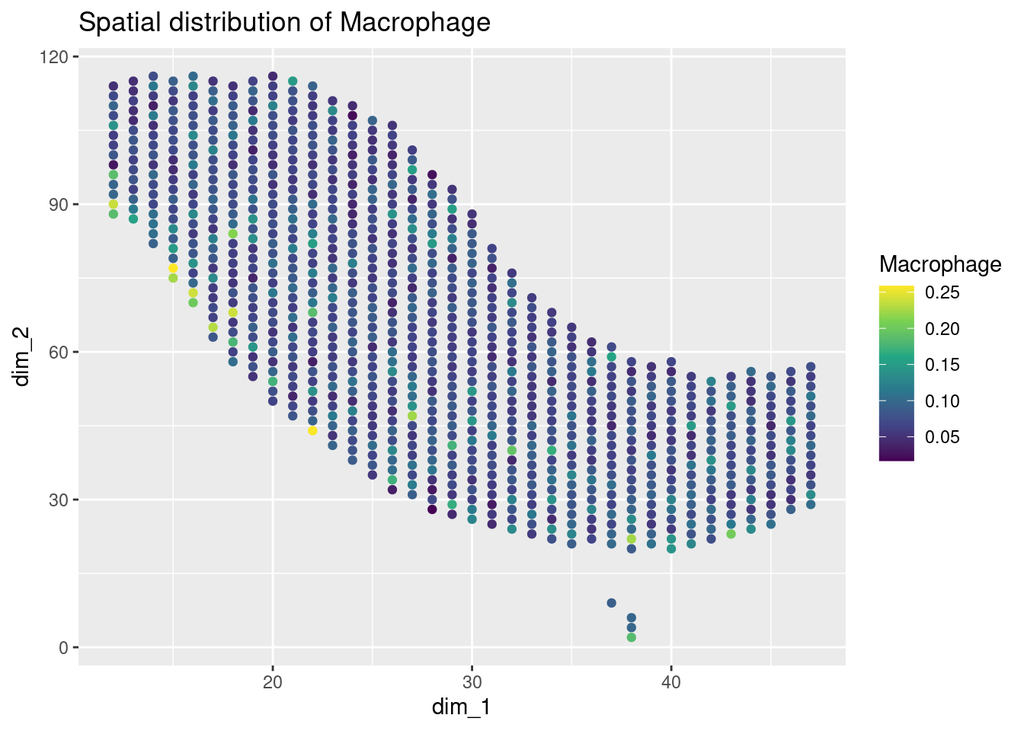

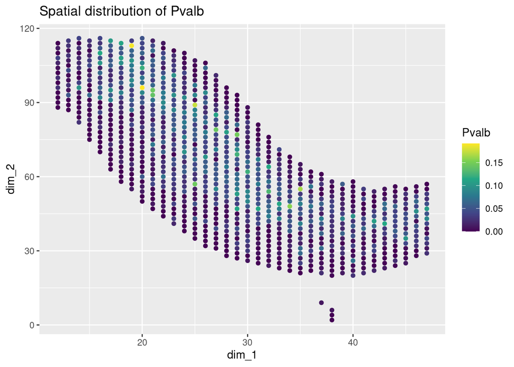

```r
plotSpatialFeatures(cortex_liger, cell.types = c("Astro", "L5 IT", "L2/3 IT","Macrophage","Pvalb"), return.plots = F)
```

### Breaking down deconvolveWithSingleCell

Most of the new code is encapsulated in this function.

1. Subset both objects to shared genes
2. Deconvolution
- `solveNNLS`, uses nonnegative lease squares to directly solve for H
- `deconvolve_with_v`, uses a modified version of `optimizeALS`to iteratively find H and account for batch effects in W
3. Factor assignments, tests significance of differences in factor loading between clusters and all cells to determine cell-tyoe specific factor loading, or look at plots and annotate by hand with `makeFactorPlots`.
4. Collate factors for the same cell type, normalize, multiply to the given number of cells.

### Generating synthetic data

`determine_diff`and `generate_training_known_shift` can be used to make synthetic spatial data. It only works with specific technologies for which the total number of reads in a spatial sample is equal to the reads from all cells in the sample, so not slide-seq nor ISH.

`determine_diff` takes four parameters,

- `known`, a DGE matrix for the spatial data
- `known_fract`, a matrix of cell type fractions for each sample in the spatial data
- `single_cell`, a DGE matrix for the scRNA-seq
- `assign`, a cell type assignment for each sample in the single cell data

It generates an “equivalent” bulk sample for each spatial in the training data by combining samples from the single cell data in the same proportion, and then compares the distributions of gene expression to find a difference in median expression.

`generate_training_known_shift` takes

- `assign`, a cell type assignment for each sample in the single cell data
- `single_cell`, a DGE matrix for the scRNA-seq
- `vargenes`, a vector of genes to subset to
- `batches`, a positive integer number of samples to generate`
- `shift_vec`, the difference in medians, the third item in the list returned by `determine_diff`

It returns 2 matrixes, the first of synthetic counts and the second of cell type fractions.